# Tugas Individu Praktikum Pertemuan 1 - Pemulusan

Raihana Asma Amani - G1401221039

## Library / Packages

Jika sudah ada, silakan panggil library *package* tersebut.

```r
library("forecast")
```

```r
library("graphics")
library("TTR")
library("TSA")
library("rio")
library("readxl")
```

## Impor Data

```r
data1 <- read_excel("C:/Users/raiha/Downloads/SEMESTER 5/MPDW/TUGAS INDIVIDU/1/data.mpdw1.xlsx")
```

## Eksplorasi Data

Melihat data menggunakan fungsi `View()`, struktur data menggunakan fungsi `str()`, dan dimensi data menggunakan fungsi `dim()`.

```r
View(data1)
str(data1)
```

```
## tibble [100 × 2] (S3: tbl_df/tbl/data.frame)
##  $ Tanggal: POSIXct[1:100], format: "2023-04-11" "2023-04-12" ...
##  $ SS     : chr [1:100] "3.7" "8.6" "5.2" "1.8" ...
```

```r
dim(data1)
```

```
## [1] 100   2
```

Mengubah data SS menjadi numerik dan mengubah data tersebut agar terbaca sebagai data deret waktu dengan fungsi `ts()` .

```r
data1$SS <- as.numeric(data1$SS)
data1.ts <- ts(data1$SS)
```

Menampilkan ringkasan data

```r
summary(data1.ts)
```

```
##    Min. 1st Qu.  Median    Mean 3rd Qu.    Max.
##   0.000   3.100   5.150   4.871   6.825  10.000
```

Membuat plot data deret waktu

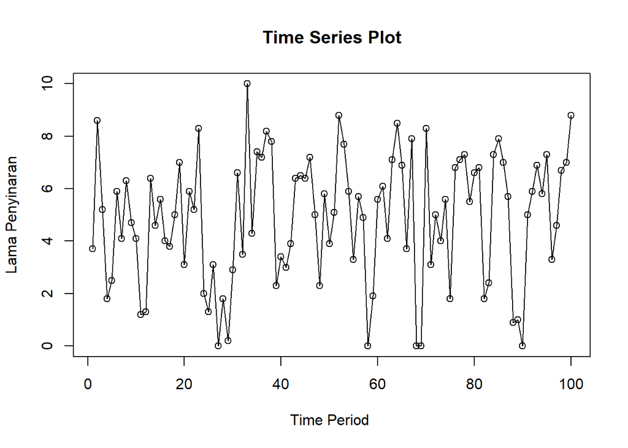

```r
ts.plot(data1.ts, xlab="Time Period ", ylab="Lama Penyinaran",
        main = "Time Series Plot")
points(data1.ts)
```

## Single Moving Average & Double Moving Average

### Pembagian Data

Pembagian data latih dan data uji dilakukan dengan perbandingan 80% data latih dan 20% data uji.

```r
# membagi data latih dan data uji
training_ma <- data1[1:80,]
testing_ma <- data1[81:100,]
train_ma.ts <- ts(training_ma$SS)
test_ma.ts <- ts(testing_ma$SS)
```

### Eksplorasi Data

Eksplorasi data dilakukan pada keseluruhan data, data latih serta data uji menggunakan plot data deret waktu.

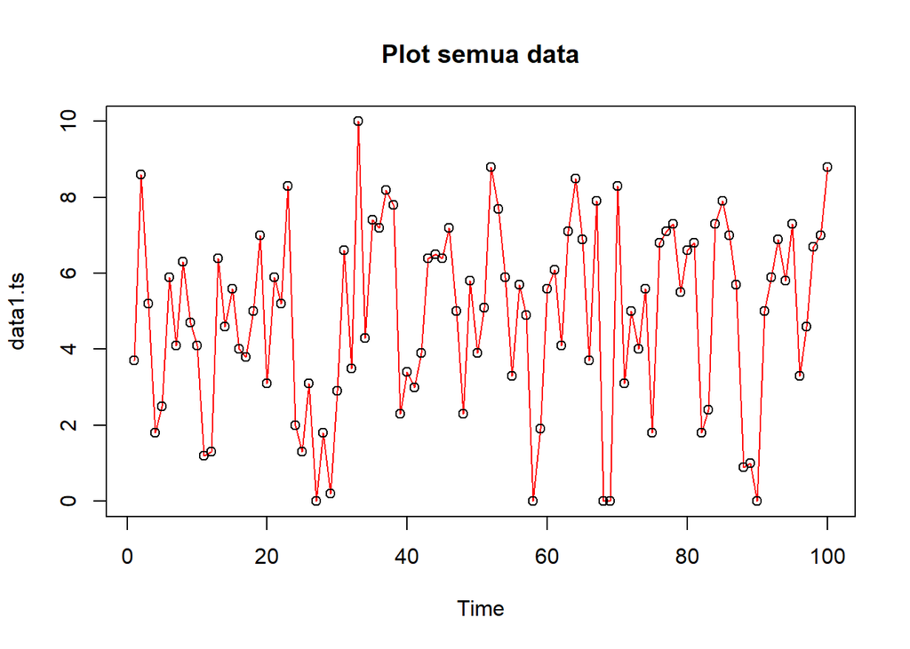

```r
#eksplorasi keseluruhan data
plot(data1.ts, col="red",main="Plot semua data")
points(data1.ts)
```

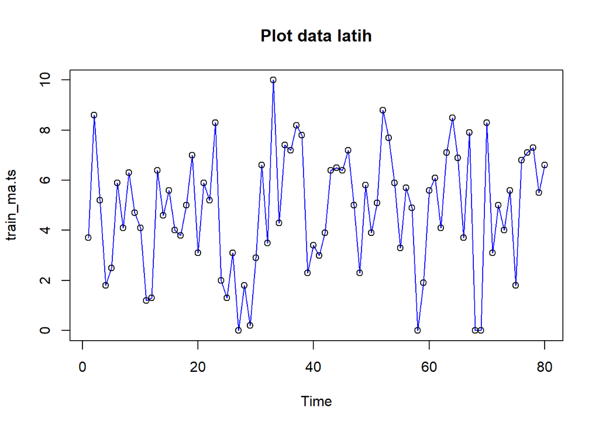

```r
#eksplorasi data latih
plot(train_ma.ts, col="blue",main="Plot data latih")
points(train_ma.ts)
```

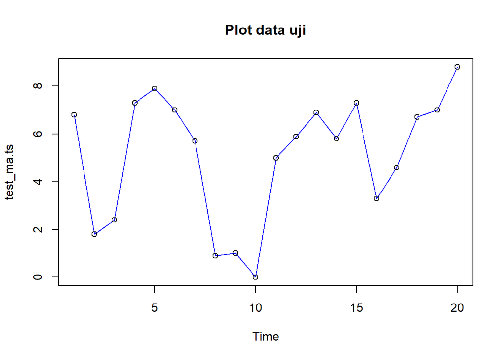

```r
#eksplorasi data uji
plot(test_ma.ts, col="blue",main="Plot data uji")
points(test_ma.ts)
```

Eksplorasi data juga dapat dilakukan menggunakan package `ggplot2` dengan terlebih dahulu memanggil library *package* `ggplot2`.

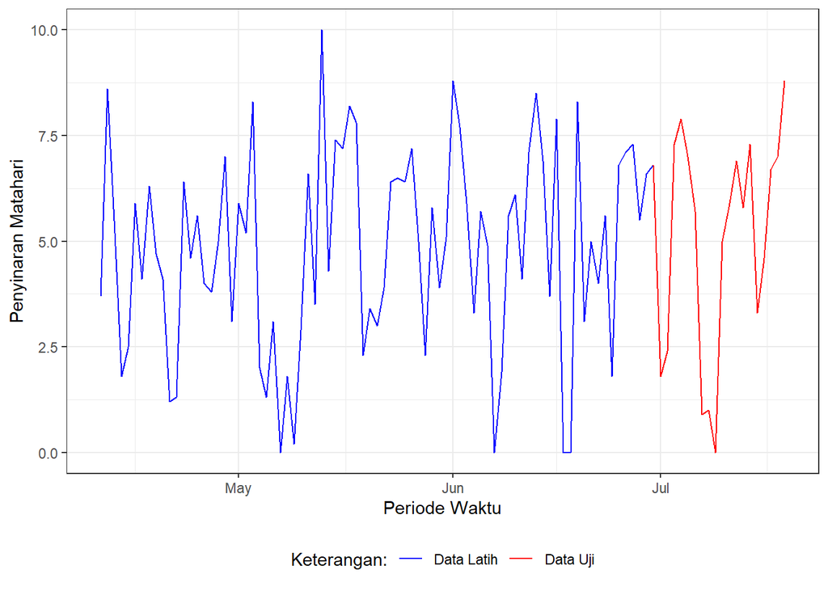

```r
#Eksplorasi dengan GGPLOT
library(ggplot2)
ggplot() +
  geom_line(data = data1, aes(x = Tanggal, y = SS, col = "Data Latih")) +
  geom_line(data =testing_ma, aes(x = Tanggal, y = SS, col = "Data Uji")) +
  labs(x = "Periode Waktu", y = "Penyinaran Matahari", color = "Legend") +
  scale_colour_manual(name="Keterangan:", breaks = c("Data Latih", "Data Uji"),
                      values = c("blue", "red")) +
  theme_bw() + theme(legend.position = "bottom",
                     plot.caption = element_text(hjust=0.5, size=12))
```

### Single Moving Average (SMA)

Ide dasar dari Single Moving Average (SMA) adalah data suatu periode dipengaruhi oleh data periode sebelumnya. Metode pemulusan ini cocok digunakan untuk pola data stasioner atau konstan. Prinsip dasar metode pemulusan ini adalah data pemulusan pada periode ke-t merupakan rata rata dari m buah data pada periode ke-t hingga periode ke (t-m+1). Data pemulusan pada periode ke-t selanjutnya digunakan sebagai nilai peramalan pada periode ke t+1

Pemulusan menggunakan metode SMA dilakukan dengan fungsi `SMA()`. Dalam hal ini akan dilakukan pemulusan dengan parameter `m=4`.

```r
data.sma<-SMA(train_ma.ts, n=4)
data.sma
```

```
## Time Series:
## Start = 1
## End = 80
## Frequency = 1
##  [1]    NA    NA    NA 4.825 4.525 3.850 3.575 4.700 5.250 4.800 4.075 2.825
## [13] 3.250 3.375 4.475 5.150 4.500 4.600 4.950 4.725 5.250 5.300 5.625 5.350
## [25] 4.200 3.675 1.600 1.550 1.275 1.225 2.875 3.300 5.750 6.100 6.300 7.225
## [37] 6.775 7.650 6.375 5.425 4.125 3.150 4.175 4.950 5.800 6.625 6.275 5.225
## [49] 5.075 4.250 4.275 5.900 6.375 6.875 6.425 5.650 4.950 3.475 3.125 3.100
## [61] 3.400 4.425 5.725 6.450 6.650 6.550 6.750 4.625 2.900 4.050 2.850 4.100
## [73] 5.100 4.425 4.100 4.550 5.325 5.750 6.675 6.625
```

Data pemulusan pada periode ke-t selanjutnya digunakan sebagai nilai peramalan pada periode ke t+1 sehingga hasil peramalan 1 periode kedepan adalah sebagai berikut.

```r
data.ramal<-c(NA,data.sma)
data.ramal #forecast 1 periode ke depan
```

```
##  [1]    NA    NA    NA    NA 4.825 4.525 3.850 3.575 4.700 5.250 4.800 4.075
## [13] 2.825 3.250 3.375 4.475 5.150 4.500 4.600 4.950 4.725 5.250 5.300 5.625
## [25] 5.350 4.200 3.675 1.600 1.550 1.275 1.225 2.875 3.300 5.750 6.100 6.300
## [37] 7.225 6.775 7.650 6.375 5.425 4.125 3.150 4.175 4.950 5.800 6.625 6.275
## [49] 5.225 5.075 4.250 4.275 5.900 6.375 6.875 6.425 5.650 4.950 3.475 3.125
## [61] 3.100 3.400 4.425 5.725 6.450 6.650 6.550 6.750 4.625 2.900 4.050 2.850
## [73] 4.100 5.100 4.425 4.100 4.550 5.325 5.750 6.675 6.625
```

Selanjutnya akan dilakukan peramalan sejumlah data uji yaitu 20 periode. Pada metode SMA, hasil peramalan 20 periode ke depan akan bernilai sama dengan hasil peramalan 1 periode kedepan. Dalam hal ini akan dilakukan pengguabungan data aktual train, data hasil pemulusan dan data hasil ramalan 20 periode kedepan.

```r
data.gab<-cbind(aktual=c(train_ma.ts,rep(NA,20)),pemulusan=c(data.sma,rep(NA,20)),ramalan=c(data.ramal,rep(data.ramal[length(data.ramal)],19)))
data.gab #forecast 20 periode ke depan
```

```
##        aktual pemulusan ramalan
##   [1,]    3.7        NA      NA
##   [2,]    8.6        NA      NA
##   [3,]    5.2        NA      NA
##   [4,]    1.8     4.825      NA
##   [5,]    2.5     4.525   4.825
##   [6,]    5.9     3.850   4.525
##   [7,]    4.1     3.575   3.850
##   [8,]    6.3     4.700   3.575
##   [9,]    4.7     5.250   4.700
##  [10,]    4.1     4.800   5.250
##  [11,]    1.2     4.075   4.800
##  [12,]    1.3     2.825   4.075
##  [13,]    6.4     3.250   2.825
##  [14,]    4.6     3.375   3.250
```

[output cut: 86 more lines]

Adapun plot data deret waktu dari hasil peramalan yang dilakukan adalah sebagai berikut.

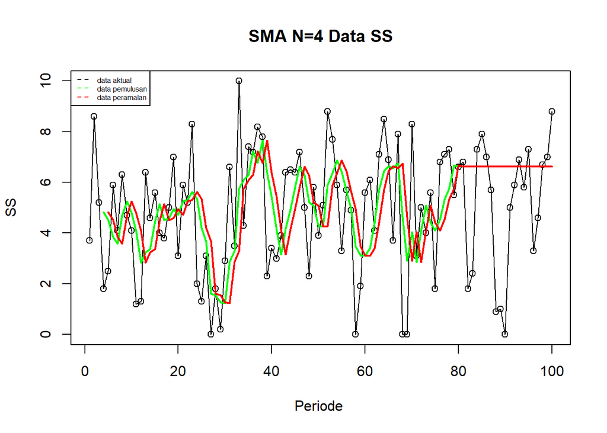

```r
ts.plot(data1.ts, xlab="Periode ", ylab="SS", main= "SMA N=4 Data SS")
points(data1.ts)
lines(data.gab[,2],col="green",lwd=2)
lines(data.gab[,3],col="red",lwd=2)
legend("topleft",c("data aktual","data pemulusan","data peramalan"), lty=8, col=c("black","green","red"), cex=0.5)
```

Selanjutnya perhitungan akurasi dilakukan dengan ukuran akurasi *Sum Squares Error* (SSE), *Mean Square Error* (MSE) dan *Mean Absolute Percentage Error* (MAPE). Perhitungan akurasi dilakukan baik pada data latih maupun pada data uji.

```r
#Menghitung nilai keakuratan data latih
error_train.sma = train_ma.ts-data.ramal[1:length(train_ma.ts)]
SSE_train.sma = sum(error_train.sma[5:length(train_ma.ts)]^2)
MSE_train.sma = mean(error_train.sma[5:length(train_ma.ts)]^2)
MAPE_train.sma = mean(abs((error_train.sma[5:length(train_ma.ts)]/train_ma.ts[5:length(train_ma.ts)])*100))

akurasi_train.sma <- matrix(c(SSE_train.sma, MSE_train.sma, MAPE_train.sma))
row.names(akurasi_train.sma)<- c("SSE", "MSE", "MAPE")
colnames(akurasi_train.sma) <- c("Akurasi m = 4")
akurasi_train.sma
```

```
##      Akurasi m = 4
## SSE     524.574375
## MSE       6.902294
## MAPE           Inf
```

Nilai MAPE yang dihitung adalah Inf karena terdapat data yang bernilai 0. Selanjutnya dilakukan perhitungan nilai MAPE data uji pada metde pemulusan SMA.

```r
#Menghitung nilai keakuratan data uji
error_test.sma = test_ma.ts-data.gab[81:100,3]
SSE_test.sma = sum(error_test.sma^2)
MSE_test.sma = mean(error_test.sma^2)
MAPE_test.sma = mean(abs((error_test.sma/test_ma.ts*100)))

akurasi_test.sma <- matrix(c(SSE_test.sma, MSE_test.sma, MAPE_test.sma))
row.names(akurasi_test.sma)<- c("SSE", "MSE", "MAPE")
colnames(akurasi_test.sma) <- c("Akurasi m = 4")
akurasi_test.sma
```

```
##      Akurasi m = 4
## SSE     176.957500
## MSE       8.847875
## MAPE           Inf
```

MAPE bernilai inf karena terdapat data yang nilainya berupa nol (0).

### Double Moving Average (DMA)

Metode pemulusan Double Moving Average (DMA) pada dasarnya mirip dengan SMA. Namun demikian, metode ini lebih cocok digunakan untuk pola data trend. Proses pemulusan dengan rata rata dalam metode ini dilakukan sebanyak 2 kali.

```r
dma <- SMA(data.sma, n = 4)
At <- 2*data.sma - dma
Bt <- 2/(4-1)*(data.sma - dma)
data.dma<- At+Bt
data.ramal2<- c(NA, data.dma)

t = 1:20
f = c()

for (i in t) {
  f[i] = At[length(At)] + Bt[length(Bt)]*(i)
}

data.gab2 <- cbind(aktual = c(train_ma.ts,rep(NA,20)), pemulusan1 = c(data.sma,rep(NA,20)),pemulusan2 = c(data.dma, rep(NA,20)),At = c(At, rep(NA,20)), Bt = c(Bt,rep(NA,20)),ramalan = c(data.ramal2, f[-1]))
data.gab2
```

```
##        aktual pemulusan1 pemulusan2       At           Bt    ramalan
##   [1,]    3.7         NA         NA       NA           NA         NA
##   [2,]    8.6         NA         NA       NA           NA         NA
##   [3,]    5.2         NA         NA       NA           NA         NA
##   [4,]    1.8      4.825         NA       NA           NA         NA
##   [5,]    2.5      4.525         NA       NA           NA         NA
##   [6,]    5.9      3.850         NA       NA           NA         NA
##   [7,]    4.1      3.575  2.5437500  2.95625 -0.412500000         NA
##   [8,]    6.3      4.700  5.5958333  5.23750  0.358333333  2.5437500
##   [9,]    4.7      5.250  6.7604167  6.15625  0.604166667  5.5958333
##  [10,]    4.1      4.800  5.1645833  5.01875  0.145833333  6.7604167
##  [11,]    1.2      4.075  3.0229167  3.44375 -0.420833333  5.1645833
##  [12,]    1.3      2.825  0.4708333  1.41250 -0.941666667  3.0229167
##  [13,]    6.4      3.250  2.4375000  2.76250 -0.325000000  0.4708333
##  [14,]    4.6      3.375  3.3645833  3.36875 -0.004166667  2.4375000
```

[output cut: 86 more lines]

Hasil pemulusan menggunakan metode DMA divisualisasikan sebagai berikut

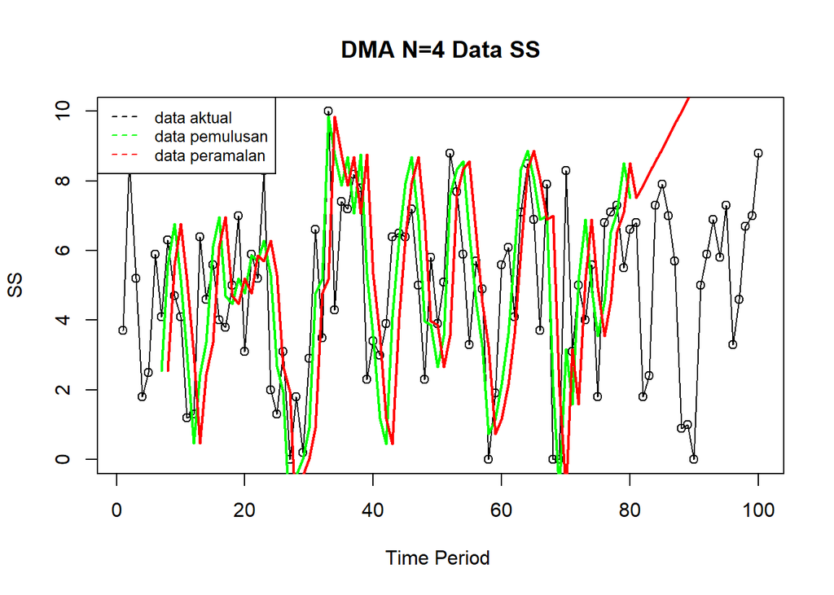

```r
ts.plot(data1.ts, xlab="Time Period ", ylab="SS", main= "DMA N=4 Data SS")
points(data1.ts)
lines(data.gab2[,3],col="green",lwd=2)
lines(data.gab2[,6],col="red",lwd=2)
legend("topleft",c("data aktual","data pemulusan","data peramalan"), lty=8, col=c("black","green","red"), cex=0.8)
```

```r
#Menghitung nilai keakuratan data latih
error_train.dma = train_ma.ts-data.ramal2[1:length(train_ma.ts)]
SSE_train.dma = sum(error_train.dma[8:length(train_ma.ts)]^2)
MSE_train.dma = mean(error_train.dma[8:length(train_ma.ts)]^2)
MAPE_train.dma = mean(abs((error_train.dma[8:length(train_ma.ts)]/train_ma.ts[8:length(train_ma.ts)])*100))

akurasi_train.dma <- matrix(c(SSE_train.dma, MSE_train.dma, MAPE_train.dma))
row.names(akurasi_train.dma)<- c("SSE", "MSE", "MAPE")
colnames(akurasi_train.dma) <- c("Akurasi m = 4")
akurasi_train.dma
```

```
##      Akurasi m = 4
## SSE      731.48991
## MSE       10.02041
## MAPE           Inf
```

Perhitungan akurasi pada data latih menggunakan nilai MAPE menghasilkan nilai MAPE Inf dikarenakan ada data yang bernilai 0

## Single Exponential Smoothing & Double Exponential Smoothing

Metode *Exponential Smoothing* adalah metode pemulusan dengan melakukan pembobotan menurun secara eksponensial. Nilai yang lebih baru diberi bobot yang lebih besar dari nilai terdahulu. Terdapat satu atau lebih parameter pemulusan yang ditentukan secara eksplisit, dan hasil pemilihan parameter tersebut akan menentukan bobot yang akan diberikan pada nilai pengamatan. Ada dua macam model, yaitu model tunggal dan ganda.

### Pembagian Data

Pembagian data latih dan data uji dilakukan dengan perbandingan 80% data latih dan 20% data uji.

```r
#membagi training dan testing
training<-data1[1:80,]
testing<-data1[81:100,]
train.ts <- ts(training$SS)
test.ts <- ts(testing$SS)
```

### Eksplorasi

Eksplorasi dilakukan dengan membuat plot data deret waktu untuk keseluruhan data, data latih, dan data uji.

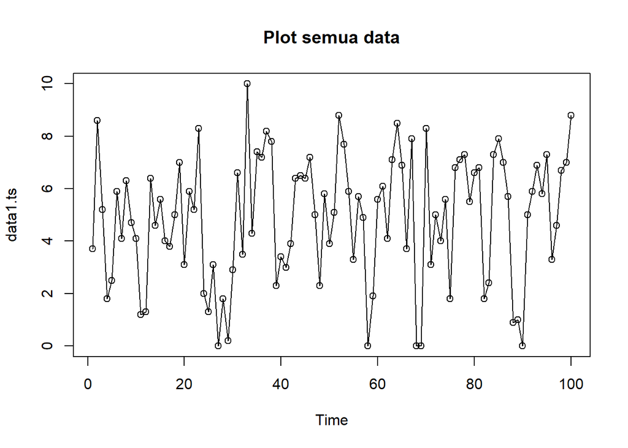

```r
#eksplorasi data
plot(data1.ts, col="black",main="Plot semua data")
points(data1.ts)
```

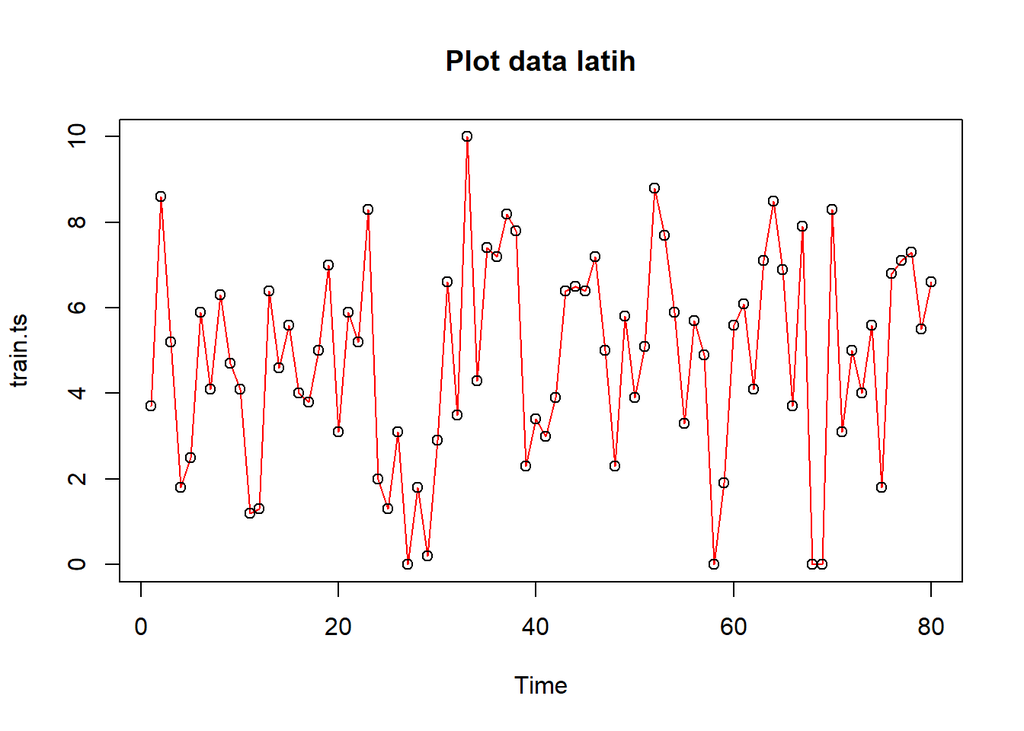

```r
plot(train.ts, col="red",main="Plot data latih")
points(train.ts)
```

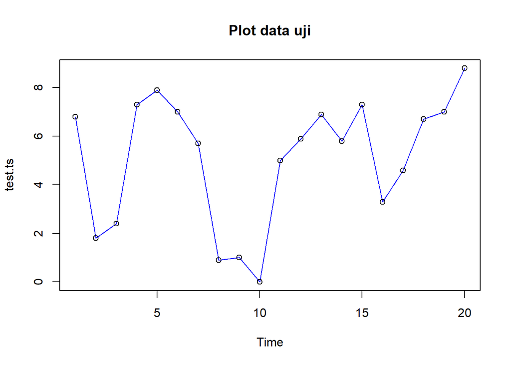

```r
plot(test.ts, col="blue",main="Plot data uji")
points(test.ts)
```

Eksplorasi data juga dapat dilakukan menggunakan package `ggplot2` .

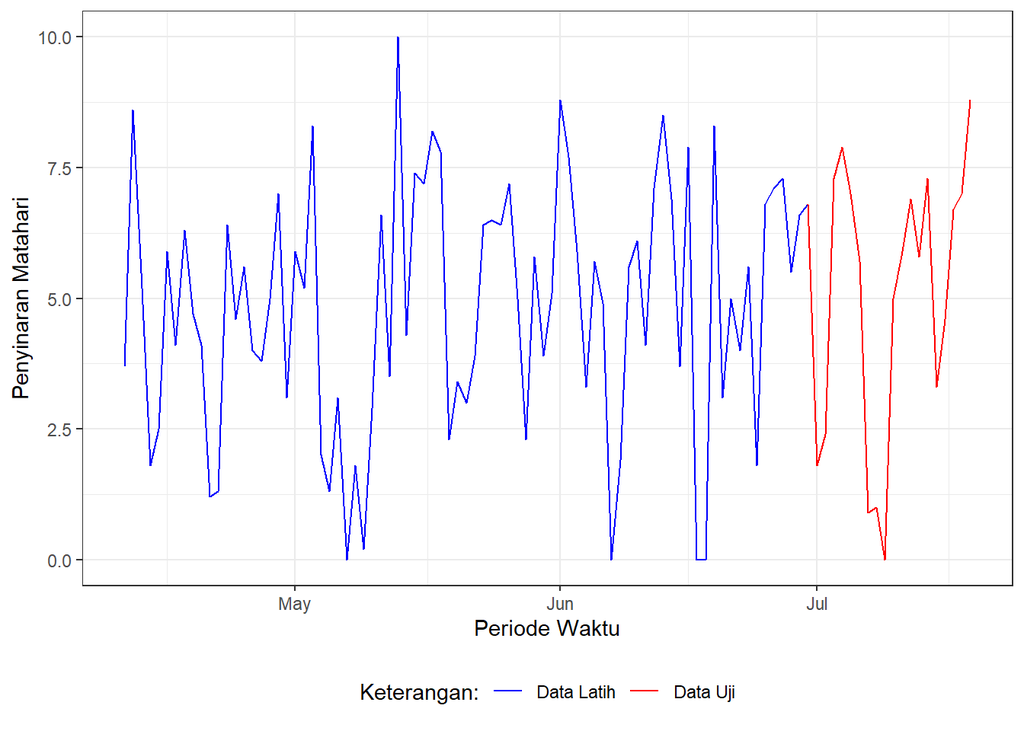

```r
#Eksplorasi dengan GGPLOT
library(ggplot2)
ggplot() +
  geom_line(data = data1, aes(x = Tanggal, y = SS, col = "Data Latih")) +
  geom_line(data = testing, aes(x = Tanggal , y = SS, col = "Data Uji")) +
  labs(x = "Periode Waktu", y = "Penyinaran Matahari", color = "Legend") +
  scale_colour_manual(name="Keterangan:", breaks = c("Data Latih", "Data Uji"),
                      values = c("blue", "red")) +
  theme_bw() + theme(legend.position = "bottom",
                     plot.caption = element_text(hjust=0.5, size=12))
```

### SES

Single Exponential Smoothing merupakan metode pemulusan yang tepat digunakan untuk data dengan pola stasioner atau konstan.

Nilai pemulusan pada periode ke-t didapat dari persamaan:

$$\tilde{y}_T=\lambda y_t+(1-\lambda)\tilde{y}_{T-1}$$

Nilai parameter $\lambda$ adalah nilai antara 0 dan 1.

Nilai pemulusan periode ke-t bertindak sebagai nilai ramalan pada periode ke-$(T+\tau)$.

$$\tilde{y}_{T+\tau}(T)=\tilde{y}_T$$

Pemulusan dengan metode SES dapat dilakukan dengan dua fungsi dari *packages* berbeda, yaitu (1) fungsi `ses()` dari *packages* `forecast` dan (2) fungsi `HoltWinters` dari *packages* `stats` .

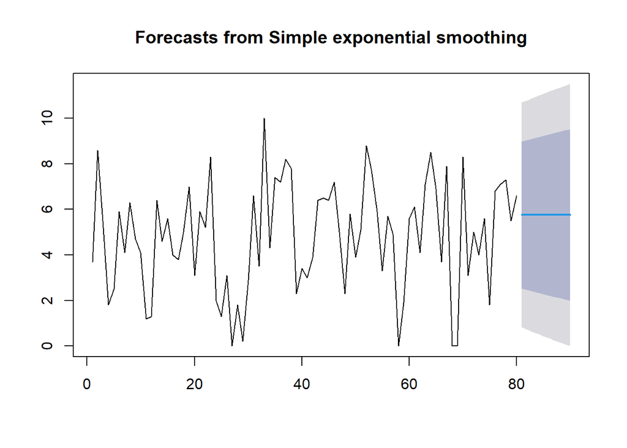

```r
#Cara 1 (fungsi ses)
ses.1 <- ses(train.ts, h = 10, alpha = 0.2)
plot(ses.1)
```

```r
ses.1
```

```
##    Point Forecast    Lo 80    Hi 80        Lo 95    Hi 95
## 81        5.75562 2.527885 8.983356  0.819225077 10.69202
## 82        5.75562 2.463963 9.047278  0.721465184 10.78978
## 83        5.75562 2.401259 9.109981  0.625567896 10.88567
## 84        5.75562 2.339706 9.171534  0.531430641 10.97981
## 85        5.75562 2.279243 9.231998  0.438959926 11.07228
## 86        5.75562 2.219813 9.291427  0.348070257 11.16317
## 87        5.75562 2.161366 9.349874  0.258683208 11.25256
## 88        5.75562 2.103855 9.407386  0.170726628 11.34051
## 89        5.75562 2.047235 9.464006  0.084133964 11.42711
## 90        5.75562 1.991466 9.519774 -0.001156333 11.51240
```

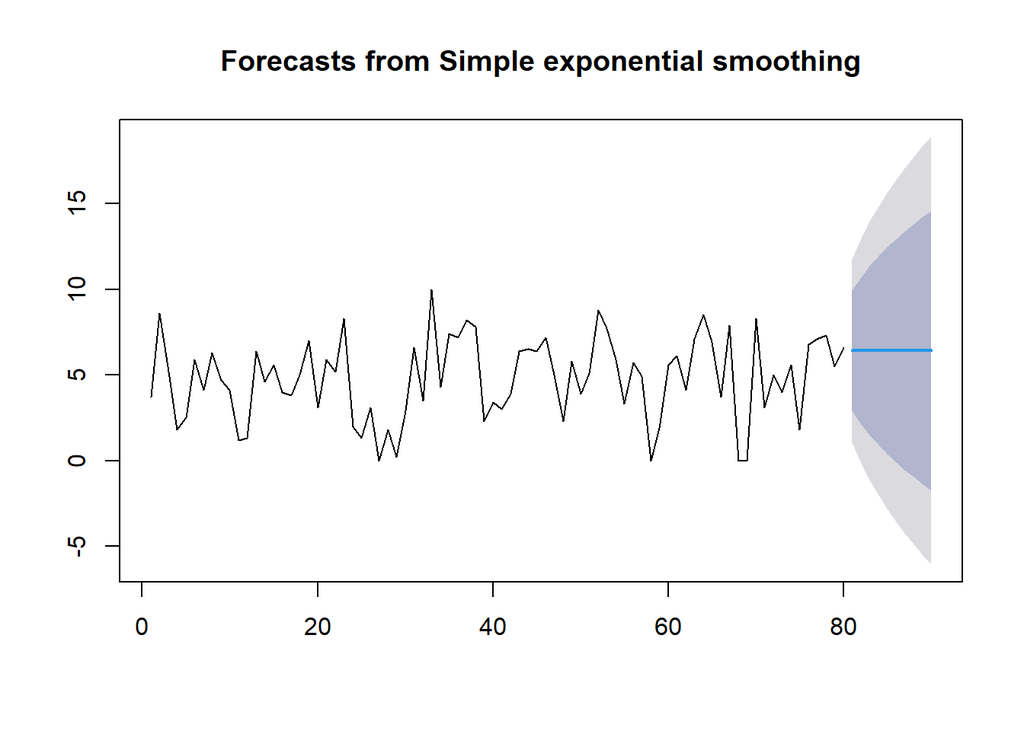

```r
ses.2<- ses(train.ts, h = 10, alpha = 0.7)
plot(ses.2)
```

```r
ses.2
```

```
##    Point Forecast      Lo 80     Hi 80     Lo 95    Hi 95
## 81       6.414486  2.9029966  9.925975  1.044127 11.78484
## 82       6.414486  2.1281670 10.700804 -0.140873 12.96984
## 83       6.414486  1.4733826 11.355589 -1.142279 13.97125
## 84       6.414486  0.8957474 11.933224 -2.025696 14.85467
## 85       6.414486  0.3730915 12.455880 -2.825029 15.65400
## 86       6.414486 -0.1078157 12.936787 -3.560514 16.38948
## 87       6.414486 -0.5556211 13.384592 -4.245373 17.07434
## 88       6.414486 -0.9763438 13.805315 -4.888812 17.71778
## 89       6.414486 -1.3743738 14.203345 -5.497547 18.32652
## 90       6.414486 -1.7530295 14.582001 -6.076651 18.90562
```

Untuk mendapatkan gambar hasil pemulusan pada data latih dengan fungsi `ses()` , perlu digunakan fungsi `autoplot()` dan `autolayer()` dari *library packages* `ggplot2` .

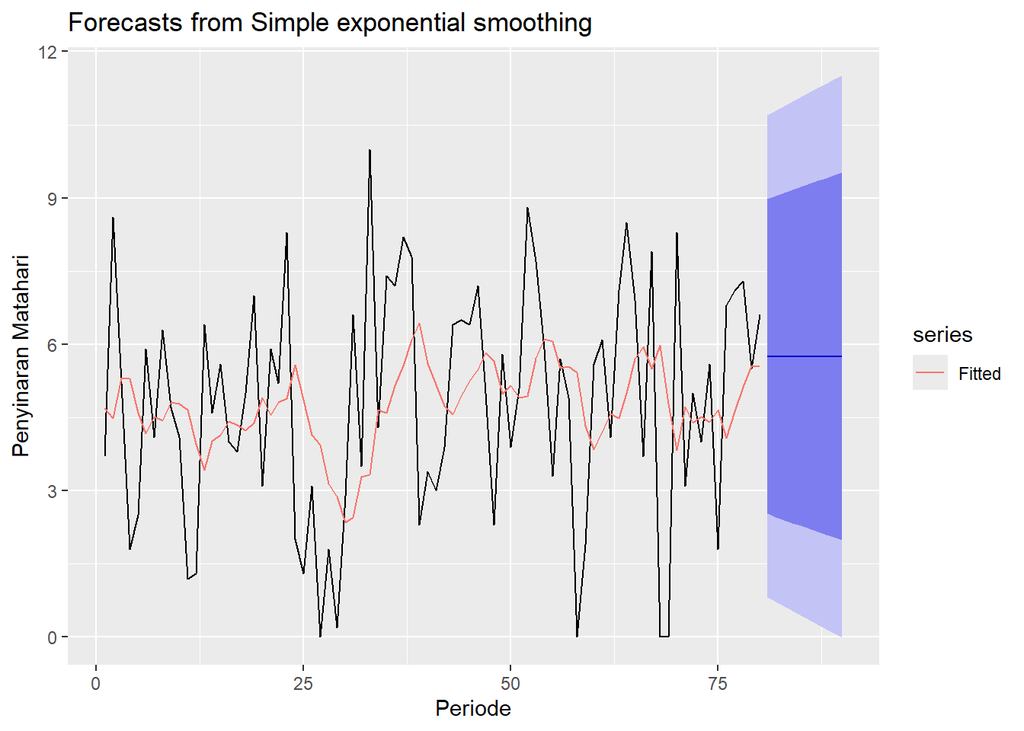

```r
autoplot(ses.1) +
  autolayer(fitted(ses.1), series="Fitted") +
  ylab("Penyinaran Matahari") + xlab("Periode")
```

Pada fungsi `ses()` , terdapat beberapa argumen yang umum digunakan, yaitu nilia `y` , `gamma` , `beta` , `alpha` , dan `h` .

Nilai `y` adalah nilai data deret waktu, `gamma` adalah parameter pemulusan untuk komponen musiman, `beta` adalah parameter pemulusan untuk tren, dan `alpha` adalah parameter pemulusan untuk stasioner, serta `h` adalah banyaknya periode yang akan diramalkan.

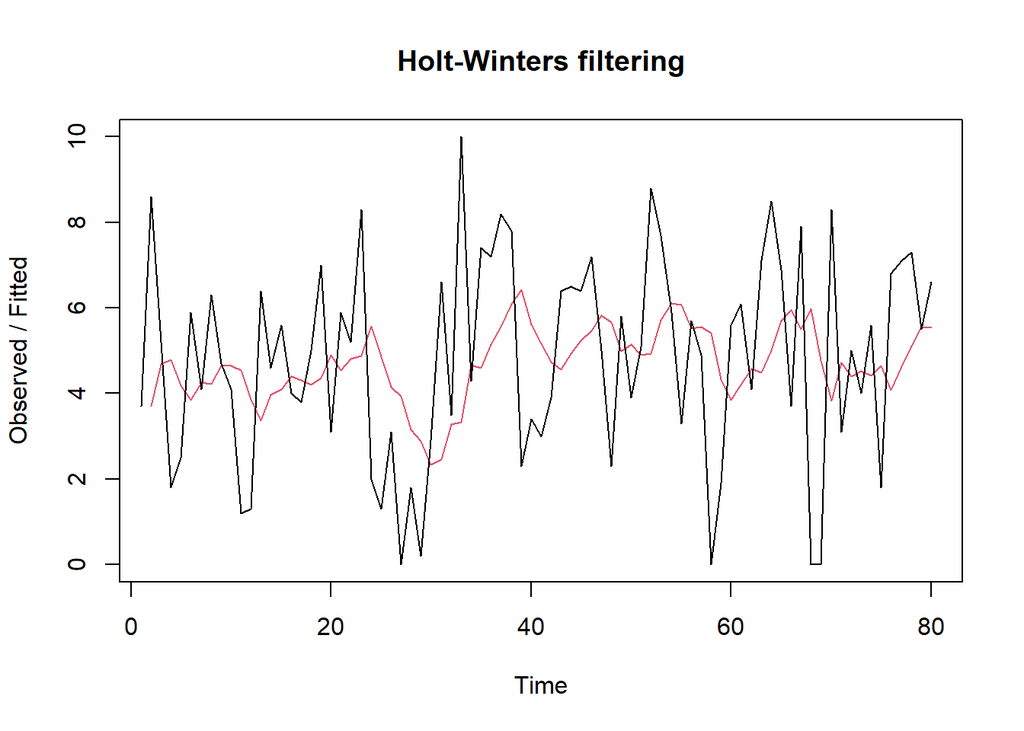

```r
#Cara 2 (fungsi Holtwinter)
ses1<- HoltWinters(train.ts, gamma = FALSE, beta = FALSE, alpha = 0.2)
plot(ses1)
```

```r
#ramalan
ramalan1<- forecast(ses1, h=20)
ramalan1
```

```
##     Point Forecast    Lo 80     Hi 80        Lo 95    Hi 95
##  81        5.75562 2.523239  8.988002  0.812120031 10.69912
##  82        5.75562 2.459225  9.052015  0.714219431 10.79702
##  83        5.75562 2.396431  9.114809  0.618184117 10.89306
##  84        5.75562 2.334790  9.176451  0.523911368 10.98733
##  85        5.75562 2.274239  9.237001  0.431307559 11.07993
##  86        5.75562 2.214724  9.296517  0.340287072 11.17095
##  87        5.75562 2.156193  9.355048  0.250771366 11.26047
##  88        5.75562 2.098599  9.412642  0.162688189 11.34855
##  89        5.75562 2.041897  9.469344  0.075970890 11.43527
##  90        5.75562 1.986049  9.525192 -0.009442165 11.52068
##  91        5.75562 1.931015  9.580225 -0.093608115 11.60485
##  92        5.75562 1.876763  9.634478 -0.176580039 11.68782
##  93        5.75562 1.823259  9.687982 -0.258407358 11.76965
##  94        5.75562 1.770473  9.740767 -0.339136175 11.85038
##  95        5.75562 1.718378  9.792863 -0.418809577 11.93005
##  96        5.75562 1.666946  9.844295 -0.497467907 12.00871
##  97        5.75562 1.616153  9.895088 -0.575149001 12.08639
##  98        5.75562 1.565976  9.945265 -0.651888401 12.16313
##  99        5.75562 1.516392  9.994848 -0.727719547 12.23896
## 100        5.75562 1.467382 10.043859 -0.802673944 12.31391
```

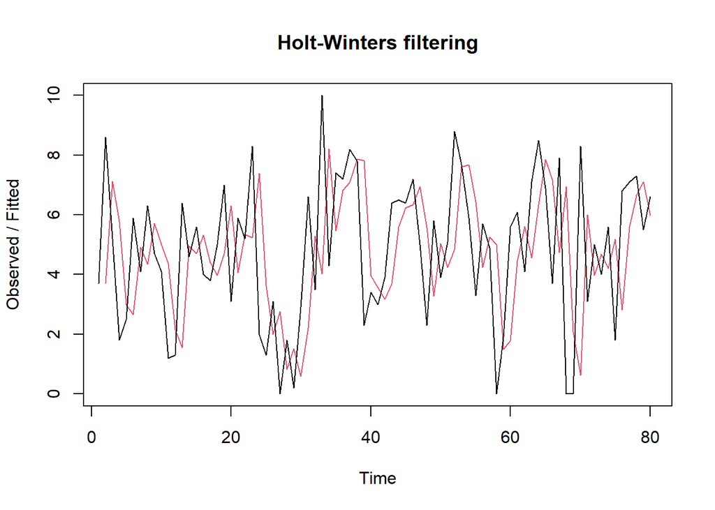

```r
ses2<- HoltWinters(train.ts, gamma = FALSE, beta = FALSE, alpha = 0.7)
plot(ses2)
```

```r
#ramalan
ramalan2<- forecast(ses2, h=20)
ramalan2
```

```
##     Point Forecast      Lo 80     Hi 80       Lo 95    Hi 95
##  81       6.414486  2.8996892  9.929282   1.0390684 11.78990
##  82       6.414486  2.1241299 10.704841  -0.1470473 12.97602
##  83       6.414486  1.4687287 11.360243  -1.1493969 13.97837
##  84       6.414486  0.8905495 11.938422  -2.0336457 14.86262
##  85       6.414486  0.3674013 12.461570  -2.8337318 15.66270
##  86       6.414486 -0.1139589 12.942930  -3.5699087 16.39888
##  87       6.414486 -0.5621860 13.391157  -4.2554129 17.08438
##  88       6.414486 -0.9833050 13.812276  -4.8994588 17.72843
##  89       6.414486 -1.3817099 14.210681  -5.5087665 18.33774
##  90       6.414486 -1.7607222 14.589693  -6.0884159 18.91739
##  91       6.414486 -2.1229251 14.951896  -6.6423574 19.47133
##  92       6.414486 -2.4703746 15.299346  -7.1737355 20.00271
##  93       6.414486 -2.8047389 15.633710  -7.6851015 20.51407
##  94       6.414486 -3.1273936 15.956365  -8.1785593 21.00753
##  95       6.414486 -3.4394891 16.268460  -8.6558682 21.48484
##  96       6.414486 -3.7419989 16.570970  -9.1185170 21.94749
##  97       6.414486 -4.0357553 16.864727  -9.5677787 22.39675
##  98       6.414486 -4.3214771 17.150448 -10.0047524 22.83372
##  99       6.414486 -4.5997894 17.428761 -10.4303943 23.25937
## 100       6.414486 -4.8712404 17.700212 -10.8455429 23.67451
```

Fungsi `HoltWinters` memiliki argumen yang sama dengan fungsi `ses()` . Argumen-argumen kedua fungsi dapat dilihat lebih lanjut dengan `?ses()` atau `?HoltWinters` .

Nilai parameter $\alpha$ dari kedua fungsi dapat dioptimalkan menyesuaikan dari *error*-nya paling minimumnya. Caranya adalah dengan membuat parameter $\alpha =$ `NULL` .

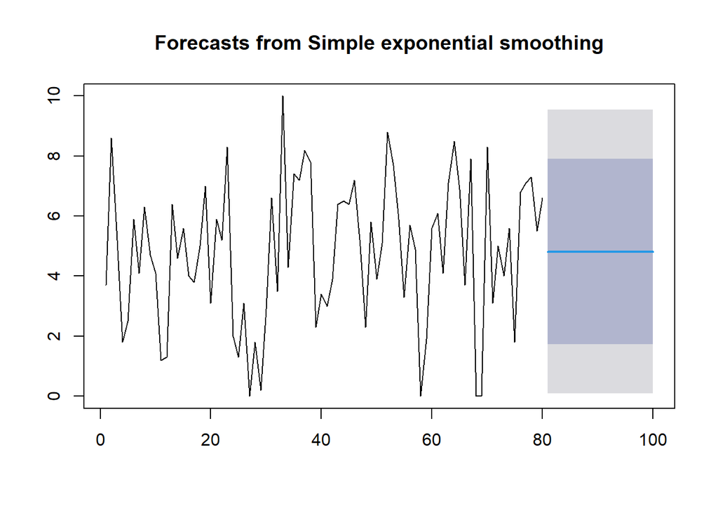

```r
#SES
ses.opt <- ses(train.ts, h = 20, alpha = NULL)
plot(ses.opt)
```

```r
ses.opt
```

```
##     Point Forecast    Lo 80    Hi 80      Lo 95    Hi 95
##  81       4.812678 1.723045 7.902312 0.08749223 9.537865
##  82       4.812678 1.723045 7.902312 0.08749221 9.537865
##  83       4.812678 1.723045 7.902312 0.08749219 9.537865
##  84       4.812678 1.723045 7.902312 0.08749216 9.537865
##  85       4.812678 1.723045 7.902312 0.08749214 9.537865
##  86       4.812678 1.723045 7.902312 0.08749212 9.537865
##  87       4.812678 1.723045 7.902312 0.08749209 9.537865
##  88       4.812678 1.723045 7.902312 0.08749207 9.537865
##  89       4.812678 1.723045 7.902312 0.08749205 9.537865
##  90       4.812678 1.723045 7.902312 0.08749202 9.537865
##  91       4.812678 1.723045 7.902312 0.08749200 9.537865
##  92       4.812678 1.723045 7.902312 0.08749197 9.537865
##  93       4.812678 1.723045 7.902312 0.08749195 9.537865
##  94       4.812678 1.723045 7.902312 0.08749193 9.537865
##  95       4.812678 1.723045 7.902312 0.08749190 9.537865
##  96       4.812678 1.723045 7.902312 0.08749188 9.537865
##  97       4.812678 1.723045 7.902312 0.08749186 9.537865
##  98       4.812678 1.723045 7.902312 0.08749183 9.537865
##  99       4.812678 1.723045 7.902312 0.08749181 9.537865
## 100       4.812678 1.723045 7.902312 0.08749179 9.537865
```

```r
#Lamda Optimum Holt Winter
sesopt<- HoltWinters(train.ts, gamma = FALSE, beta = FALSE,alpha = NULL)
sesopt
```

```
## Holt-Winters exponential smoothing without trend and without seasonal component.
##
## Call:
## HoltWinters(x = train.ts, alpha = NULL, beta = FALSE, gamma = FALSE)
##
## Smoothing parameters:
##  alpha: 0.04730732
##  beta : FALSE
##  gamma: FALSE
##
## Coefficients:
##       [,1]
## a 5.088649
```

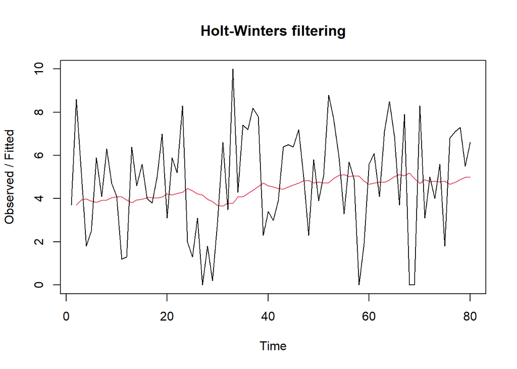

```r
plot(sesopt)
```

```r
#ramalan
ramalanopt<- forecast(sesopt, h=20)
ramalanopt
```

```
##     Point Forecast    Lo 80    Hi 80     Lo 95    Hi 95
##  81       5.088649 1.966435 8.210862 0.3136353 9.863662
##  82       5.088649 1.962943 8.214354 0.3082951 9.869002
##  83       5.088649 1.959456 8.217842 0.3029608 9.874336
##  84       5.088649 1.955972 8.221326 0.2976325 9.879665
##  85       5.088649 1.952491 8.224806 0.2923101 9.884987
##  86       5.088649 1.949015 8.228282 0.2869936 9.890304
##  87       5.088649 1.945543 8.231755 0.2816830 9.895614
##  88       5.088649 1.942074 8.235223 0.2763783 9.900919
##  89       5.088649 1.938609 8.238688 0.2710793 9.906218
##  90       5.088649 1.935148 8.242149 0.2657862 9.911511
##  91       5.088649 1.931691 8.245606 0.2604990 9.916798
##  92       5.088649 1.928238 8.249059 0.2552175 9.922080
##  93       5.088649 1.924788 8.252509 0.2499417 9.927356
##  94       5.088649 1.921342 8.255955 0.2446717 9.932626
##  95       5.088649 1.917900 8.259397 0.2394075 9.937890
##  96       5.088649 1.914462 8.262835 0.2341489 9.943148
##  97       5.088649 1.911027 8.266270 0.2288960 9.948401
##  98       5.088649 1.907596 8.269701 0.2236488 9.953648
##  99       5.088649 1.904169 8.273128 0.2184073 9.958890
## 100       5.088649 1.900745 8.276552 0.2131714 9.964126
```

Setelah dilakukan peramalan, akan dilakukan perhitungan keakuratan hasil peramalan. Perhitungan akurasi ini dilakukan baik pada data latih dan data uji.

#### Akurasi Data Latih

Perhitungan akurasi data dapat dilakukan dengan cara langsung maupun manual. Secara langsung, nilai akurasi dapat diambil dari objek yang tersimpan pada hasil SES, yaitu *sum of squared errors* (SSE). Nilai akurasi lain dapat dihitung pula dari nilai SSE tersebut.

```r
#Keakuratan Metode
#Pada data training
SSE1<-ses1$SSE
MSE1<-ses1$SSE/length(train.ts)
RMSE1<-sqrt(MSE1)

akurasi1 <- matrix(c(SSE1,MSE1,RMSE1))
row.names(akurasi1)<- c("SSE", "MSE", "RMSE")
colnames(akurasi1) <- c("Akurasi lamda=0.2")
akurasi1
```

```
##      Akurasi lamda=0.2
## SSE         497.549546
## MSE           6.219369
## RMSE          2.493866
```

```r
SSE2<-ses2$SSE
MSE2<-ses2$SSE/length(train.ts)
RMSE2<-sqrt(MSE2)

akurasi2 <- matrix(c(SSE2,MSE2,RMSE2))
row.names(akurasi2)<- c("SSE", "MSE", "RMSE")
colnames(akurasi2) <- c("Akurasi lamda=0.7")
akurasi2
```

```
##      Akurasi lamda=0.7
## SSE         586.899380
## MSE           7.336242
## RMSE          2.708550
```

```r
#Cara Manual
fitted1<-ramalan1$fitted
sisaan1<-ramalan1$residuals
head(sisaan1)
```

```
## Time Series:
## Start = 1
## End = 6
## Frequency = 1
## [1]       NA  4.90000  0.52000 -2.98400 -1.68720  2.05024
```

```r
resid1<-training$SS-ramalan1$fitted
head(resid1)
```

```
## Time Series:
## Start = 1
## End = 6
## Frequency = 1
## [1]       NA  4.90000  0.52000 -2.98400 -1.68720  2.05024
```

```r
#Cara Manual
SSE.1=sum(sisaan1[2:length(train.ts)]^2)
SSE.1
```

```
## [1] 497.5495
```

```r
MSE.1 = SSE.1/length(train.ts)
MSE.1
```

```
## [1] 6.219369
```

```r
MAPE.1 = sum(abs(sisaan1[2:length(train.ts)]/train.ts[2:length(train.ts)])*
               100)/length(train.ts)
MAPE.1
```

```
## [1] Inf
```

```r
akurasi.1 <- matrix(c(SSE.1,MSE.1,MAPE.1))
row.names(akurasi.1)<- c("SSE", "MSE", "MAPE")
colnames(akurasi.1) <- c("Akurasi lamda=0.2")
akurasi.1
```

```
##      Akurasi lamda=0.2
## SSE         497.549546
## MSE           6.219369
## MAPE               Inf
```

```r
fitted2<-ramalan2$fitted
sisaan2<-ramalan2$residuals
head(sisaan2)
```

```
## Time Series:
## Start = 1
## End = 6
## Frequency = 1
## [1]       NA  4.90000 -1.93000 -3.97900 -0.49370  3.25189
```

```r
resid2<-training$SS-ramalan2$fitted
head(resid2)
```

```
## Time Series:
## Start = 1
## End = 6
## Frequency = 1
## [1]       NA  4.90000 -1.93000 -3.97900 -0.49370  3.25189
```

```r
SSE.2=sum(sisaan2[2:length(train.ts)]^2)
SSE.2
```

```
## [1] 586.8994
```

```r
MSE.2 = SSE.2/length(train.ts)
MSE.2
```

```
## [1] 7.336242
```

```r
MAPE.2 = sum(abs(sisaan2[2:length(train.ts)]/train.ts[2:length(train.ts)])*
               100)/length(train.ts)
MAPE.2
```

```
## [1] Inf
```

```r
akurasi.2 <- matrix(c(SSE.2,MSE.2,MAPE.2))
row.names(akurasi.2)<- c("SSE", "MSE", "MAPE")
colnames(akurasi.2) <- c("Akurasi lamda=0.7")
akurasi.2
```

```
##      Akurasi lamda=0.7
## SSE         586.899380
## MSE           7.336242
## MAPE               Inf
```

#### Akurasi Data Uji

Akurasi data uji dapat dihitung dengan cara yang hampir sama dengan perhitungan akurasi data latih.

```r
selisih1<-ramalan1$mean-testing$SS
SSEtesting1<-sum(selisih1^2)
MSEtesting1<-SSEtesting1/length(testing)

selisih2<-ramalan2$mean-testing$SS
SSEtesting2<-sum(selisih2^2)
MSEtesting2<-SSEtesting2/length(testing)

selisihopt<-ramalanopt$mean-testing$SS
SSEtestingopt<-sum(selisihopt^2)
MSEtestingopt<-SSEtestingopt/length(testing)

akurasitesting1 <- matrix(c(SSEtesting1,SSEtesting2,SSEtestingopt))
row.names(akurasitesting1)<- c("SSE1", "SSE2", "SSEopt")
akurasitesting1
```

```
##            [,1]
## SSE1   139.2156
## SSE2   165.0446
## SSEopt 130.7548
```

```r
akurasitesting2 <- matrix(c(MSEtesting1,MSEtesting2,MSEtestingopt))
row.names(akurasitesting2)<- c("MSE1", "MSE2", "MSEopt")
akurasitesting2
```

```
##            [,1]
## MSE1   69.60782
## MSE2   82.52228
## MSEopt 65.37742
```

Selain dengan cara di atas, perhitungan nilai akurasi dapat menggunakan fungsi `accuracy()` dari *package* `forecast` . Penggunaannya yaitu dengan menuliskan `accuracy(hasil ramalan, kondisi aktual)` . Contohnya adalah sebagai berikut.

```r
#cara lain
accuracy(ramalanopt,testing$SS)
```

```
##                      ME     RMSE      MAE  MPE MAPE      MASE      ACF1
## Training set 0.37156685 2.449157 2.019835 -Inf  Inf 0.8402684 0.1855304
## Test set     0.01635134 2.556901 2.187270 -Inf  Inf 0.9099229        NA
```

### DES

Metode pemulusan *Double Exponential Smoothing* (DES) digunakan untuk data yang memiliki pola tren. Metode DES adalah metode semacam SES, hanya saja dilakukan dua kali, yaitu pertama untuk tahapan ‘level’ dan kedua untuk tahapan ‘tren’. Pemulusan menggunakan metode ini akan menghasilkan peramalan tidak konstan untuk periode berikutnya.

Pemulusan dengan metode DES kali ini akan menggunakan fungsi `HoltWinters()` . Jika sebelumnya nilai argumen `beta` dibuat `FALSE` , kali ini argumen tersebut akan diinisialisasi bersamaan dengan nilai `alpha` .

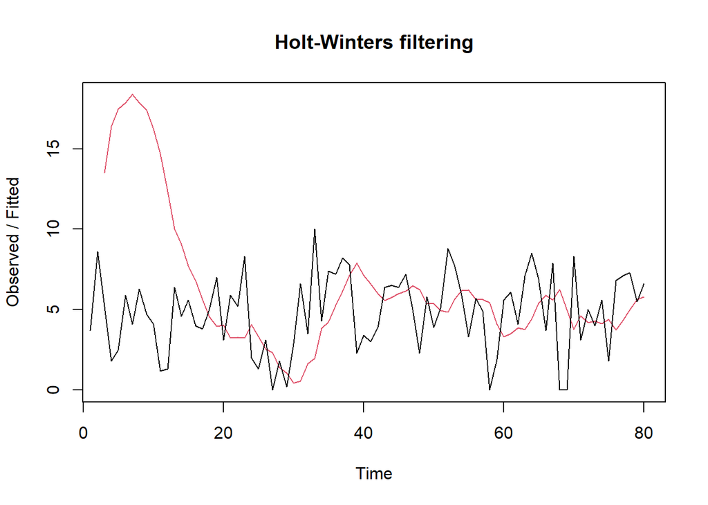

```r
#Lamda=0.2 dan gamma=0.2
des.1<- HoltWinters(train.ts, gamma = FALSE, beta = 0.2, alpha = 0.2)
plot(des.1)
```

```r
#ramalan
ramalandes1<- forecast(des.1, h=20)
ramalandes1
```

```
##     Point Forecast      Lo 80    Hi 80      Lo 95    Hi 95
##  81       6.173012 -0.3312925 12.67732  -3.774463 16.12049
##  82       6.389352 -0.2996546 13.07836  -3.840601 16.61930
##  83       6.605691 -0.3268117 13.53819  -3.996657 17.20804
##  84       6.822030 -0.4161826 14.06024  -4.247861 17.89192
##  85       7.038370 -0.5691648 14.64590  -4.596350 18.67309
##  86       7.254709 -0.7854114 15.29483  -5.041594 19.55101
##  87       7.471049 -1.0632339 16.00533  -5.581010 20.52311
##  88       7.687388 -1.4000361 16.77481  -6.210628 21.58540
##  89       7.903727 -1.7927057 17.60016  -6.925687 22.73314
##  90       8.120067 -2.2379239 18.47806  -7.721113 23.96125
##  91       8.336406 -2.7323845 19.40520  -8.591848 25.26466
##  92       8.552745 -3.2729323 20.37842  -9.533068 26.63856
##  93       8.769085 -3.8566405 21.39481 -10.540296 28.07847
##  94       8.985424 -4.4808433 22.45169 -11.609455 29.58030
##  95       9.201763 -5.1431413 23.54667 -12.736875 31.14040
##  96       9.418103 -5.8413900 24.67760 -13.919278 32.75548
##  97       9.634442 -6.5736799 25.84256 -15.153741 34.42263
##  98       9.850782 -7.3383131 27.03988 -16.437670 36.13923
##  99      10.067121 -8.1337790 28.26802 -17.768753 37.90300
## 100      10.283460 -8.9587316 29.52565 -19.144933 39.71185
```

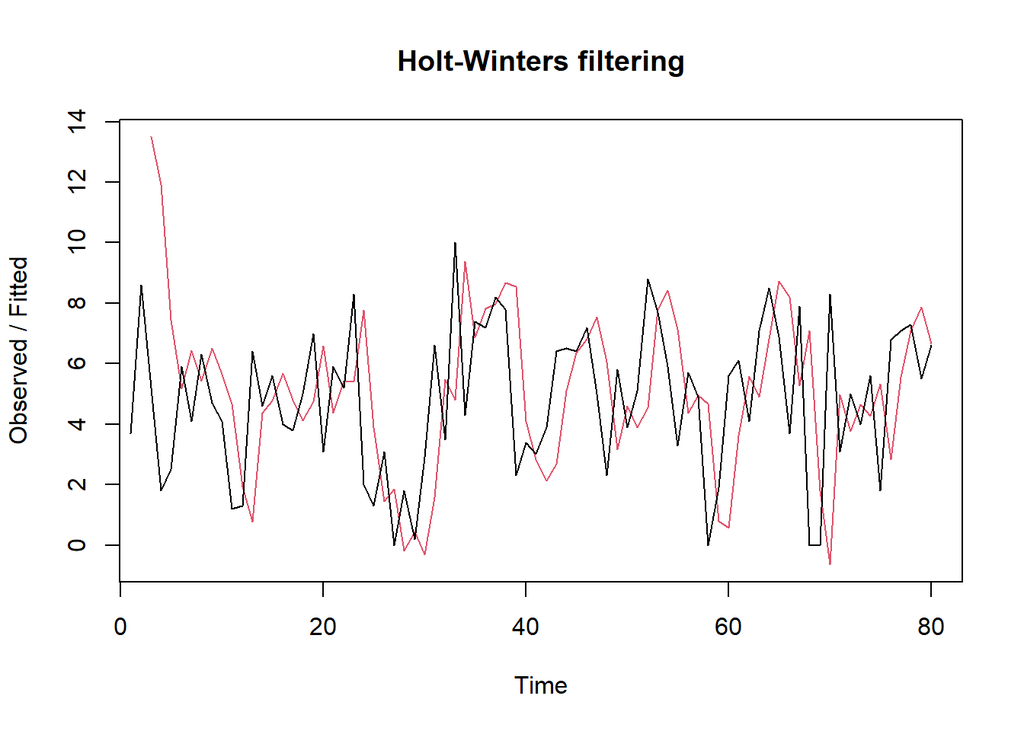

```r
#Lamda=0.6 dan gamma=0.3
des.2<- HoltWinters(train.ts, gamma = FALSE, beta = 0.3, alpha = 0.6)
plot(des.2)
```

```r
#ramalan
ramalandes2<- forecast(des.2, h=20)
ramalandes2
```

```
##     Point Forecast       Lo 80    Hi 80       Lo 95    Hi 95
##  81       6.842037   2.6555961 11.02848   0.4394282 13.24465
##  82       7.054430   1.7450721 12.36379  -1.0655322 15.17439
##  83       7.266823   0.6078809 13.92576  -2.9171501 17.45080
##  84       7.479216  -0.7133829 15.67181  -5.0502826 20.00871
##  85       7.691609  -2.1905205 17.57374  -7.4218037 22.80502
##  86       7.904001  -3.8045690 19.61257 -10.0027119 25.81071
##  87       8.116394  -5.5421860 21.77497 -12.7726017 29.00539
##  88       8.328787  -7.3935143 24.05109 -15.7163979 32.37397
##  89       8.541180  -9.3509456 26.43331 -18.8224648 35.90482
##  90       8.753573 -11.4083892 28.91554 -22.0814873 39.58863
##  91       8.965966 -13.5608213 31.49275 -25.4857820 43.41771
##  92       9.178359 -15.8039974 34.16071 -29.0288579 47.38558
##  93       9.390752 -18.1342619 36.91577 -32.7051239 51.48663
##  94       9.603144 -20.5484159 39.75470 -36.5096877 55.71598
##  95       9.815537 -23.0436240 42.67470 -40.4382133 60.06929
##  96      10.027930 -25.6173466 45.67321 -44.4868163 64.54268
##  97      10.240323 -28.2672881 48.74793 -48.6519860 69.13263
##  98      10.452716 -30.9913579 51.89679 -52.9305253 73.83596
##  99      10.665109 -33.7876401 55.11786 -57.3195039 78.64972
## 100      10.877502 -36.6543687 58.40937 -61.8162210 83.57122
```

Selanjutnya jika ingin membandingkan plot data latih dan data uji adalah sebagai berikut.

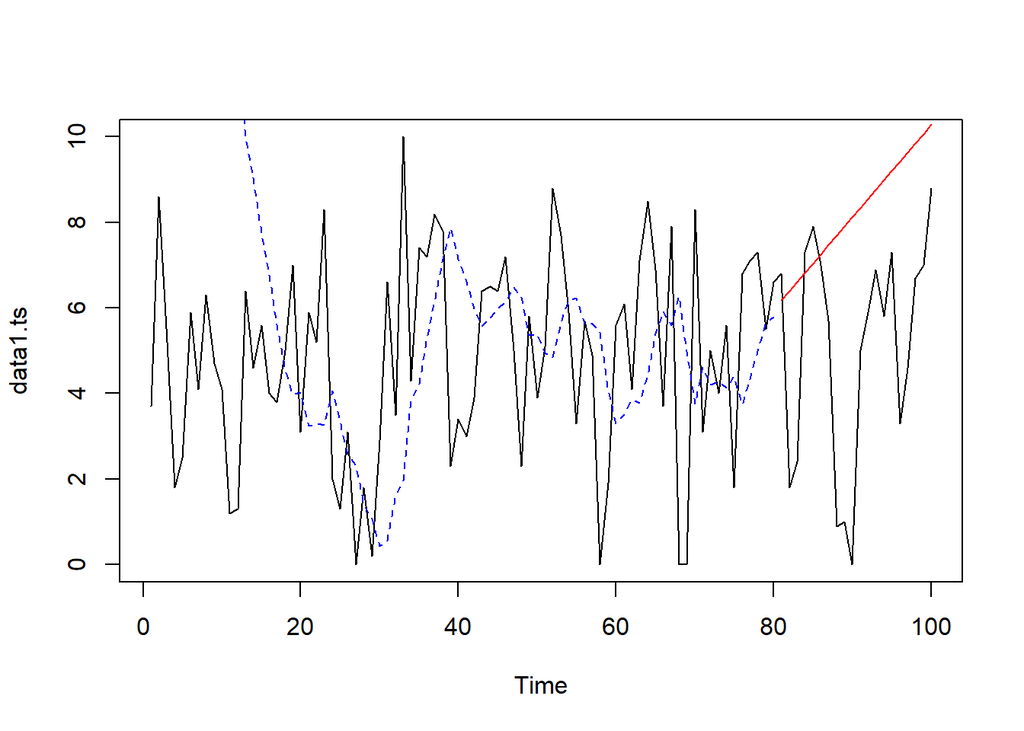

```r
#Visually evaluate the prediction
plot(data1.ts)
lines(des.1$fitted[,1], lty=2, col="blue")
lines(ramalandes1$mean, col="red")
```

Untuk mendapatkan nilai parameter optimum dari DES, argumen `alpha` dan `beta` dapat dibuat `NULL` seperti berikut.

```r
#Lamda dan gamma optimum
des.opt<- HoltWinters(train.ts, gamma = FALSE)
des.opt
```

```
## Holt-Winters exponential smoothing with trend and without seasonal component.
##
## Call:
## HoltWinters(x = train.ts, gamma = FALSE)
##
## Smoothing parameters:
##  alpha: 0.6756875
##  beta : 0.2361108
##  gamma: FALSE
##
## Coefficients:
##        [,1]
## a 6.5413227
## b 0.2019756
```

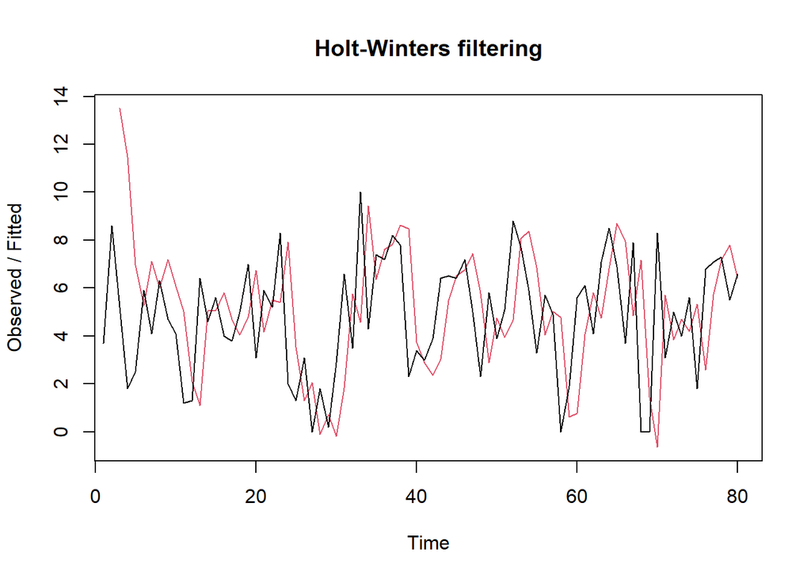

```r
plot(des.opt)
```

```r
#ramalan
ramalandesopt<- forecast(des.opt, h=20)
ramalandesopt
```

```
##     Point Forecast       Lo 80    Hi 80       Lo 95    Hi 95
##  81       6.743298   2.5800193 10.90658   0.3761126 13.11048
##  82       6.945274   1.5208552 12.36969  -1.3506587 15.24121
##  83       7.147250   0.3225814 13.97192  -3.2901798 17.58468
##  84       7.349225  -0.9976629 15.69611  -5.4162385 20.11469
##  85       7.551201  -2.4282765 17.53068  -7.7110927 22.81349
##  86       7.753177  -3.9607765 19.46713 -10.1617688 25.66812
##  87       7.955152  -5.5885933 21.49890 -12.7582191 28.66852
##  88       8.157128  -7.3064203 23.62068 -15.4923282 31.80658
##  89       8.359104  -9.1098360 25.82804 -18.3573340 35.07554
##  90       8.561079 -10.9950693 28.11723 -21.3474690 38.46963
##  91       8.763055 -12.9588448 30.48495 -24.4577238 41.98383
##  92       8.965031 -14.9982769 32.92834 -27.6836855 45.61375
##  93       9.167006 -17.1107943 35.44481 -31.0214215 49.35543
##  94       9.368982 -19.2940837 38.03205 -34.4673940 53.20536
##  95       9.570957 -21.5460475 40.68796 -38.0183950 57.16031
##  96       9.772933 -23.8647711 43.41064 -41.6714960 61.21736
##  97       9.974909 -26.2484962 46.19831 -45.4240085 65.37383
##  98      10.176884 -28.6956007 49.04937 -49.2734512 69.62722
##  99      10.378860 -31.2045806 51.96230 -53.2175244 73.97524
## 100      10.580836 -33.7740368 54.93571 -57.2540879 78.41576
```

Selanjutnya akan dilakukan perhitungan akurasi pada data latih maupun data uji dengan ukuran akurasi SSE, MSE dan MAPE.

#### Akurasi Data Latih

```r
#Akurasi Data Training
ssedes.train1<-des.1$SSE
msedes.train1<-ssedes.train1/length(train.ts)
sisaandes1<-ramalandes1$residuals
head(sisaandes1)
```

```
## Time Series:
## Start = 1
## End = 6
## Frequency = 1
## [1]        NA        NA  -8.30000 -14.60800 -14.97008 -11.96094
```

```r
mapedes.train1 <- sum(abs(sisaandes1[3:length(train.ts)]/train.ts[3:length(train.ts)])
                      *100)/length(train.ts)

akurasides.1 <- matrix(c(ssedes.train1,msedes.train1,mapedes.train1))
row.names(akurasides.1)<- c("SSE", "MSE", "MAPE")
colnames(akurasides.1) <- c("Akurasi lamda=0.2 dan gamma=0.2")
akurasides.1
```

```
##      Akurasi lamda=0.2 dan gamma=0.2
## SSE                       2159.22041
## MSE                         26.99026
## MAPE                             Inf
```

```r
ssedes.train2<-des.2$SSE
msedes.train2<-ssedes.train2/length(train.ts)
sisaandes2<-ramalandes2$residuals
head(sisaandes2)
```

```
## Time Series:
## Start = 1
## End = 6
## Frequency = 1
## [1]          NA          NA  -8.3000000 -10.1260000  -4.9337200   0.7312616
```

```r
mapedes.train2 <- sum(abs(sisaandes2[3:length(train.ts)]/train.ts[3:length(train.ts)])
                      *100)/length(train.ts)

akurasides.2 <- matrix(c(ssedes.train2,msedes.train2,mapedes.train2))
row.names(akurasides.2)<- c("SSE", "MSE", "MAPE")
colnames(akurasides.2) <- c("Akurasi lamda=0.6 dan gamma=0.3")
akurasides.2
```

```
##      Akurasi lamda=0.6 dan gamma=0.3
## SSE                        830.38579
## MSE                         10.37982
## MAPE                             Inf
```

Hasil akurasi dari data latih didapatkan skenario 2 dengan lamda=0.6 dan gamma=0.3 memiliki hasil yang lebih baik.

#### Akurasi Data Uji

```r
#Akurasi Data Testing
selisihdes1<-ramalandes1$mean-testing$SS
selisihdes1
```

```
## Time Series:
## Start = 81
## End = 100
## Frequency = 1
##  [1] -0.6269877  4.5893517  4.2056911 -0.4779696 -0.8616302  0.2547092
##  [7]  1.7710485  6.7873879  6.9037273  8.1200666  3.3364060  2.6527454
## [13]  1.8690847  3.1854241  1.9017635  6.1181028  5.0344422  3.1507816
## [19]  3.0671209  1.4834603
```

```r
SSEtestingdes1<-sum(selisihdes1^2)
MSEtestingdes1<-SSEtestingdes1/length(testing$SS)
MAPEtestingdes1<-sum(abs(selisihdes1/testing$SS)*100)/length(testing$SS)

selisihdes2<-ramalandes2$mean-testing$SS
selisihdes2
```

```
## Time Series:
## Start = 81
## End = 100
## Frequency = 1
##  [1]  0.04203708  5.25442995  4.86682282  0.17921569 -0.20839143  0.90400144
##  [7]  2.41639431  7.42878718  7.54118006  8.75357293  3.96596580  3.27835867
## [13]  2.49075154  3.80314442  2.51553729  6.72793016  5.64032303  3.75271590
## [19]  3.66510878  2.07750165
```

```r
SSEtestingdes2<-sum(selisihdes2^2)
MSEtestingdes2<-SSEtestingdes2/length(testing$SS)
MAPEtestingdes2<-sum(abs(selisihdes2/testing$SS)*100)/length(testing$SS)

selisihdesopt<-ramalandesopt$mean-testing$SS
selisihdesopt
```

```
## Time Series:
## Start = 81
## End = 100
## Frequency = 1
##  [1] -0.05670162  5.14527402  4.74724967  0.04922532 -0.34879903  0.75317661
##  [7]  2.25515226  7.25712791  7.35910356  8.56107921  3.76305485  3.06503050
## [13]  2.26700615  3.56898180  2.27095744  6.47293309  5.37490874  3.47688439
## [19]  3.37886003  1.78083568
```

```r
SSEtestingdesopt<-sum(selisihdesopt^2)
MSEtestingdesopt<-SSEtestingdesopt/length(testing$SS)
MAPEtestingdesopt<-sum(abs(selisihdesopt/testing$SS)*100)/length(testing$SS)

akurasitestingdes <-
  matrix(c(SSEtestingdes1,MSEtestingdes1,MAPEtestingdes1,SSEtestingdes2,MSEtestingdes2,
           MAPEtestingdes2,SSEtestingdesopt,MSEtestingdesopt,MAPEtestingdesopt),
         nrow=3,ncol=3)
row.names(akurasitestingdes)<- c("SSE", "MSE", "MAPE")
colnames(akurasitestingdes) <- c("des ske1","des ske2","des opt")
akurasitestingdes
```

```
##       des ske1  des ske2   des opt
## SSE  322.71889 409.09220 378.95939
## MSE   16.13594  20.45461  18.94797
## MAPE       Inf       Inf       Inf
```

#### Perbandingan SES dan DES

```r
MSEfull <-
  matrix(c(MSEtesting1,MSEtesting2,MSEtestingopt,MSEtestingdes1,MSEtestingdes2,
           MSEtestingdesopt),nrow=3,ncol=2)
row.names(MSEfull)<- c("ske 1", "ske 2", "ske opt")
colnames(MSEfull) <- c("ses","des")
MSEfull
```

```
##              ses      des
## ske 1   69.60782 16.13594
## ske 2   82.52228 20.45461
## ske opt 65.37742 18.94797
```

Kedua metode dapat dibandingkan dengan menggunakan ukuran akurasi yang sama. Contoh di atas adalah perbandingan kedua metode dengan ukuran akurasi MSE. Hasilnya didapatkan metode DES lebih baik dibandingkan metode SES dilihat dari MSE yang lebih kecil nilainya.

## Pemulusan Data Musiman

```r
#membagi data menjadi training dan testing
training<-data1[1:80,2]
testing<-data1[81:100,2]
training.ts<-ts(training, frequency = 10)
testing.ts<-ts(testing, frequency = 10)
```

# Winter Aditif

Perhitungan dengan model aditif dilakukan jika plot data asli menunjukkan fluktuasi musiman yang relatif stabil (konstan).

Pemulusan

```r
#Pemulusan dengan winter aditif
winter1 <- HoltWinters(training.ts,alpha=0.2,beta=0.1,gamma=0.1,seasonal = "additive")
winter1$fitted
```

```
## Time Series:
## Start = c(2, 1)
## End = c(8, 10)
## Frequency = 10
##           xhat    level         trend      season
## 2.0  0.7908636 4.157000  3.363636e-03 -3.36950000
## 2.1  1.0942373 4.242191  1.154636e-02 -3.15950000
## 2.2  6.3310514 4.294890  1.566162e-02  2.02050000
## 2.3  4.5118817 4.324341  1.704059e-02  0.17050000
## 2.4  5.4833083 4.359005  1.880295e-02  1.10550000
## 2.5  5.5127835 4.401147  2.113679e-02  1.09050000
## 2.6  3.8911079 4.119727 -9.118882e-03 -0.21950000
## 2.7  6.3669453 4.092386 -1.094104e-02  2.28550000
## 2.8  4.2552763 3.808056 -3.827994e-02  0.48550000
## 2.9  3.9258355 4.318721  1.661453e-02 -0.40950000
## 3.0  0.8334972 4.170168  9.781881e-05 -3.33676909
## 3.1  2.1419557 5.183567  1.014279e-01 -3.14303898
## 3.2  8.0852082 5.896604  1.625888e-01  2.02601589
## 3.3  6.4465847 6.102151  1.668846e-01  0.17754946
## 3.4  6.5725066 5.379718  7.795290e-02  1.11483533
## 3.5  5.3451500 4.403170 -2.749723e-02  0.96947732
## 3.6  3.6274538 3.926643 -7.240023e-02 -0.22678863
## 3.7  5.1599468 3.128752 -1.449493e-01  2.17614438
## 3.8  2.8047427 2.311813 -2.121482e-01  0.70507790
## 3.9  0.8389063 1.578716 -2.642431e-01 -0.47556684
## 4.0 -1.4277782 1.726692 -2.230212e-01 -2.93144886
## 4.1  0.1483652 3.109226 -6.246566e-02 -2.89839544
## 4.2  5.7648539 3.717088  4.567038e-03  2.04319923
## 4.3  4.4797765 4.568684  8.926996e-02 -0.17817732
## 4.4  5.4007078 4.621999  8.567443e-02  0.69303481
## 4.5  6.0230570 5.107531  1.256603e-01  0.78986532
## 4.6  5.1007945 5.468580  1.491991e-01 -0.51698494
## 4.7  8.3561524 6.237621  2.111832e-01  1.90734864
## 4.8  7.0343320 6.337573  2.000602e-01  0.49669848
## 4.9  5.3854613 5.590767  1.053736e-01 -0.31067935
## 5.0  3.0754861 5.299048  6.566433e-02 -2.28922661
## 5.1  2.7835055 5.349615  6.415461e-02 -2.63026466
## 5.2  8.1055644 5.637069  8.648450e-02  2.38201092
## 5.3  5.2422544 5.382441  5.237321e-02 -0.19255944
## 5.4  6.6168693 5.686363  7.752812e-02  0.85297819
```

[output cut: 20 more lines]

```
## 7.5  6.7737939 5.847048  7.852574e-02  0.84822062
## 7.6  4.9756333 5.310814  1.704986e-02 -0.35223104
## 7.7  6.8606624 5.912738  7.553719e-02  0.87238754
## 7.8  4.5649361 4.616142 -6.167605e-02  0.01046971
## 7.9  3.1971043 3.641479 -1.529748e-01 -0.29140006
## 8.0  2.7263371 4.509083 -5.091686e-02 -1.73182958
## 8.1  2.5546285 4.532899 -4.344360e-02 -1.93482715
## 8.2  7.1366046 4.978530  5.463828e-03  2.15261084
## 8.3  4.4624318 4.356673 -5.726826e-02  0.16302724
## 8.4  5.0566216 4.526918 -3.451690e-02  0.56422028
## 8.5  4.3437448 3.841077 -9.964933e-02  0.60231711
## 8.6  4.0638728 4.232679 -5.052423e-02 -0.11828170
## 8.7  5.1231128 4.789380  1.019832e-02  0.32353455
## 8.8  4.9339666 5.234956  5.373606e-02 -0.35472517
## 8.9  5.5837868 5.401898  6.505673e-02  0.11683160
```

```r
xhat1 <- winter1$fitted[,2]

winter1.opt<- HoltWinters(training.ts, alpha= NULL,  beta = NULL, gamma = NULL, seasonal = "additive")
winter1.opt
```

```
## Holt-Winters exponential smoothing with trend and additive seasonal component.
##
## Call:
## HoltWinters(x = training.ts, alpha = NULL, beta = NULL, gamma = NULL,     seasonal = "additive")
##
## Smoothing parameters:
##  alpha: 0
##  beta : 0
##  gamma: 0.3033109
##
## Coefficients:
##             [,1]
## a    4.392454545
## b    0.003363636
## s1  -0.135998698
## s2   0.415425905
## s3   2.045787196
## s4   1.638337780
## s5   0.047370648
## s6   1.338636976
## s7   1.776458621
## s8  -0.531446022
## s9  -0.988499450
## s10  1.452235686
```

```r
winter1.opt$fitted
```

```
## Time Series:
## Start = c(2, 1)
## End = c(8, 10)
## Frequency = 10
##          xhat    level       trend      season
## 2.0 0.7908636 4.157000 0.003363636 -3.36950000
## 2.1 1.0042273 4.160364 0.003363636 -3.15950000
## 2.2 6.1875909 4.163727 0.003363636  2.02050000
## 2.3 4.3409545 4.167091 0.003363636  0.17050000
## 2.4 5.2793182 4.170455 0.003363636  1.10550000
## 2.5 5.2676818 4.173818 0.003363636  1.09050000
## 2.6 3.9610455 4.177182 0.003363636 -0.21950000
## 2.7 6.4694091 4.180545 0.003363636  2.28550000
## 2.8 4.6727727 4.183909 0.003363636  0.48550000
## 2.9 3.7811364 4.187273 0.003363636 -0.40950000
## 3.0 0.9485955 4.190636 0.003363636 -3.24540449
## 3.1 1.1275747 4.194000 0.003363636 -3.06978891
## 3.2 6.2856533 4.197364 0.003363636  2.08492599
## 3.3 4.4531622 4.200727 0.003363636  0.24907130
## 3.4 5.4102208 4.204091 0.003363636  1.20276628
## 3.5 4.9168165 4.207455 0.003363636  0.70599831
## 3.6 3.9458350 4.210818 0.003363636 -0.26834684
## 3.7 6.0573577 4.214182 0.003363636  1.83981223
## 3.8 5.4122824 4.217545 0.003363636  1.19137335
## 3.9 3.6081767 4.220909 0.003363636 -0.61609607
## 4.0 2.4840467 4.224273 0.003363636 -1.74358963
## 4.1 2.3964220 4.227636 0.003363636 -1.83457802
## 4.2 6.9302629 4.231000 0.003363636  2.69589927
## 4.3 3.7427278 4.234364 0.003363636 -0.49499949
## 4.4 4.1971825 4.237727 0.003363636 -0.04390841
## 4.5 4.3993926 4.241091 0.003363636  0.15493810
## 4.6 2.7826567 4.244455 0.003363636 -1.46516152
## 4.7 4.7996911 4.247818 0.003363636  0.54850933
## 4.8 3.8649768 4.251182 0.003363636 -0.38956862
## 4.9 3.4270153 4.254545 0.003363636 -0.83089376
## 5.0 3.7660965 4.257909 0.003363636 -0.49517622
## 5.1 2.7647856 4.261273 0.003363636 -1.49985080
## 5.2 7.8949839 4.264636 0.003363636  3.62698393
## 5.3 3.9453909 4.268000 0.003363636 -0.32597276
## 5.4 5.2022683 4.271364 0.003363636  0.92754098
```

[output cut: 20 more lines]

```
## 7.5 5.8713883 4.342000 0.003363636  1.52602462
## 7.6 4.7643609 4.345364 0.003363636  0.41563360
## 7.7 3.3307758 4.348727 0.003363636 -1.02131511
## 7.8 3.5208755 4.352091 0.003363636 -0.83457902
## 7.9 4.2554728 4.355455 0.003363636 -0.10334543
## 8.0 4.7164787 4.358818 0.003363636  0.35429688
## 8.1 4.6856150 4.362182 0.003363636  0.32006950
## 8.2 7.4659595 4.365545 0.003363636  3.09705043
## 8.3 6.1893741 4.368909 0.003363636  1.81710135
## 8.4 5.5649605 4.372273 0.003363636  1.18932413
## 8.5 5.2464189 4.375636 0.003363636  0.86741894
## 8.6 5.7490707 4.379000 0.003363636  1.36670707
## 8.7 2.3541516 4.382364 0.003363636 -2.03157565
## 8.8 2.4865920 4.385727 0.003363636 -1.90249887
## 8.9 5.5158582 4.389091 0.003363636  1.12340369
```

```r
xhat1.opt <- winter1.opt$fitted[,2]
```

#### Peramalan

```r
#Forecast
forecast1 <- predict(winter1, n.ahead = 20)
forecast1.opt <- predict(winter1.opt, n.ahead = 20)
```

#### Plot Deret Waktu

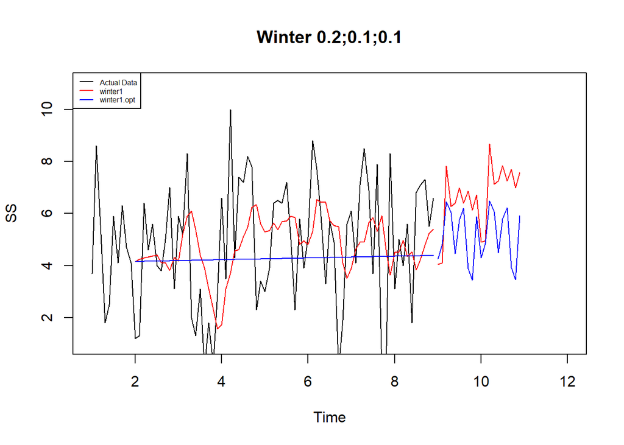

```r
#Plot time series
plot(training.ts,main="Winter 0.2;0.1;0.1",type="l",col="black",
     xlim=c(1,12), ylim=c(1,11),pch=12)
lines(xhat1,type="l",col="red")
lines(xhat1.opt,type="l",col="blue")
lines(forecast1,type="l",col="red")
lines(forecast1.opt,type="l",col="blue")
legend("topleft",c("Actual Data",expression(paste(winter1)),
                   expression(paste(winter1.opt))),cex=0.5,
       col=c("black","red","blue"),lty=1)
```

#### Akurasi Data Latih

```r
#Akurasi data training
SSE1<-winter1$SSE
MSE1<-winter1$SSE/length(training.ts)
RMSE1<-sqrt(MSE1)
akurasi1 <- matrix(c(SSE1,MSE1,RMSE1))
row.names(akurasi1)<- c("SSE", "MSE", "RMSE")
colnames(akurasi1) <- c("Akurasi")
akurasi1
```

```
##         Akurasi
## SSE  629.374357
## MSE    7.867179
## RMSE   2.804849
```

```r
SSE1.opt<-winter1.opt$SSE
MSE1.opt<-winter1.opt$SSE/length(training.ts)
RMSE1.opt<-sqrt(MSE1.opt)
akurasi1.opt <- matrix(c(SSE1.opt,MSE1.opt,RMSE1.opt))
row.names(akurasi1.opt)<- c("SSE1.opt", "MSE1.opt", "RMSE1.opt")
colnames(akurasi1.opt) <- c("Akurasi")
akurasi1.opt
```

```
##              Akurasi
## SSE1.opt  478.790677
## MSE1.opt    5.984883
## RMSE1.opt   2.446402
```

```r
akurasi1.train = data.frame(Model_Winter = c("Winter 1","Winter1 optimal"),
                            Nilai_SSE=c(SSE1,SSE1.opt),
                            Nilai_MSE=c(MSE1,MSE1.opt),Nilai_RMSE=c(RMSE1,RMSE1.opt))
akurasi1.train
```

```
##      Model_Winter Nilai_SSE Nilai_MSE Nilai_RMSE
## 1        Winter 1  629.3744  7.867179   2.804849
## 2 Winter1 optimal  478.7907  5.984883   2.446402
```

#### Akurasi Data Uji

```r
#Akurasi Data Testing
forecast1<-data.frame(forecast1)
testing.ts<-data.frame(testing.ts)
selisih1<-forecast1-testing.ts
SSEtesting1<-sum(selisih1^2)
MSEtesting1<-SSEtesting1/length(testing.ts)

forecast1.opt<-data.frame(forecast1.opt)
selisih1.opt<-forecast1.opt-testing.ts
SSEtesting1.opt<-sum(selisih1.opt^2)
MSEtesting1.opt<-SSEtesting1.opt/length(testing.ts)
```